# Residuals Outliers and Predictions

Mike LeVan

2025-03-12

## Exercises

In this assignment, you will be told which data set and two different quantitative variables to analyse. The data sets are already built into R so you don’t have to download any of the data. You will create scatterplots with linear models using `ggplot2`, determine any possible outliers or influential observations, calculate the residuals, make a residual plot, and use the linear model to make three predictions, where one of the values is an example of extrapolation.

**Steps**

1. **Create a Scatterplot with Linear Model:**
   - Use `ggplot2` to create a scatterplot of the two variables.
   - Add a linear model to the scatterplot using `geom_smooth` with the `lm` method.
2. **Determine Possible Outliers or Influential Observations:**
   - Identify any potential outliers or influential points from the scatterplot.
3. **Calculate Residuals:**
   - Fit a linear model using `lm()`.
   - Extract the residuals from the model.
4. **Make a Residual Plot:**
   - Create a residual plot using `ggplot2`.
5. **Make Predictions Using the Linear Model:**
   - Use the `predict()` function to make three predictions.
   - Ensure that one of the values used for prediction is an example of extrapolation (a value outside the range of the original data).

### Problem 1: Iris Dataset - Sepal Length vs Petal Length

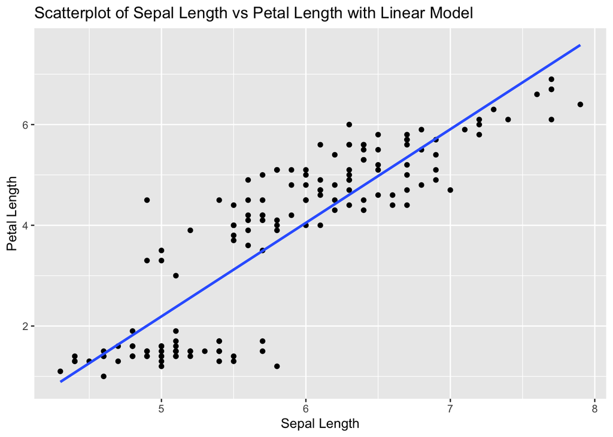

```r
# Load ggplot2 and iris dataset
library(ggplot2)
data(iris)

# Scatterplot with linear model
ggplot(iris, aes(x = Sepal.Length, y = Petal.Length)) +
  geom_point() +
  geom_smooth(method = "lm", se = FALSE) +
  labs(title = "Scatterplot of Sepal Length vs Petal Length with Linear Model", x = "Sepal Length", y = "Petal Length")
```

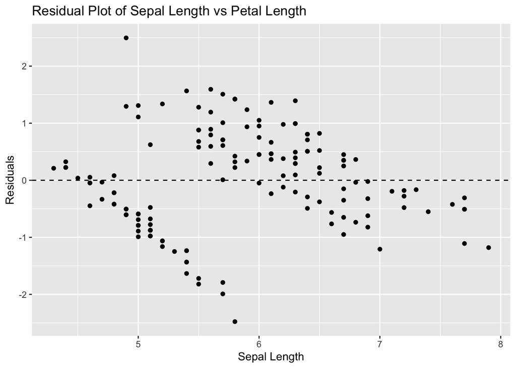

```r
# Fit linear model
model_iris <- lm(Petal.Length ~ Sepal.Length, data = iris)

# Calculate residuals
residuals_iris <- resid(model_iris)

# Residual plot
ggplot(iris, aes(x = Sepal.Length, y = residuals_iris)) +
  geom_point() +
  geom_hline(yintercept = 0, linetype = "dashed") +
  labs(title = "Residual Plot of Sepal Length vs Petal Length", x = "Sepal Length", y = "Residuals")
```

```r
# Make predictions
predictions <- predict(model_iris, newdata = data.frame(Sepal.Length = c(5, 6, 10))) # 10 is extrapolated
predictions
```

```
##         1         2         3
##  2.190722  4.049154 11.482886
```

### Problem 2: Airquality Dataset - Ozone vs Wind

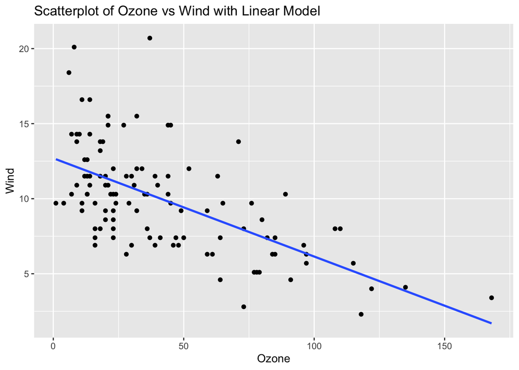

```r
# Load ggplot2 and airquality dataset
library(ggplot2)
data(airquality)

# Remove NA values
airquality_clean <- na.omit(airquality)

# Scatterplot with linear model
ggplot(airquality_clean, aes(x = Ozone, y = Wind)) +
  geom_point() +
  geom_smooth(method = "lm", se = FALSE) +
  labs(title = "Scatterplot of Ozone vs Wind with Linear Model", x = "Ozone", y = "Wind")
```

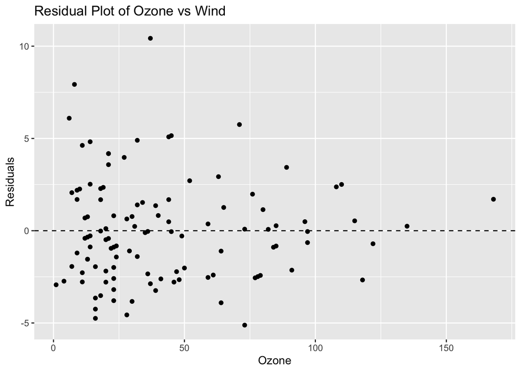

```r
# Fit linear model
model_airquality <- lm(Wind ~ Ozone, data = airquality_clean)

# Calculate residuals
residuals_airquality <- resid(model_airquality)

# Residual plot
ggplot(airquality_clean, aes(x = Ozone, y = residuals_airquality)) +
  geom_point() +
  geom_hline(yintercept = 0, linetype = "dashed") +
  labs(title = "Residual Plot of Ozone vs Wind", x = "Ozone", y = "Residuals")
```

```r
# Make predictions
predictions <- predict(model_airquality, newdata = data.frame(Ozone = c(50, 100, 200))) # 200 is extrapolated
predictions
```

```
##          1          2          3
##  9.4222467  6.1479811 -0.4005501
```

### Problem 3: ToothGrowth Dataset - Dose vs Length

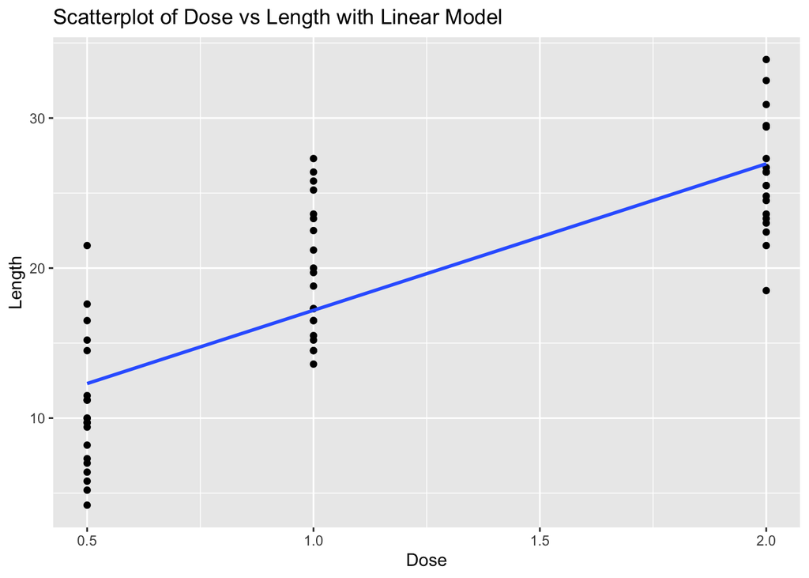

```r
# Load ggplot2 and ToothGrowth dataset
library(ggplot2)
data(ToothGrowth)

# Scatterplot with linear model
ggplot(ToothGrowth, aes(x = dose, y = len)) +
  geom_point() +
  geom_smooth(method = "lm", se = FALSE) +
  labs(title = "Scatterplot of Dose vs Length with Linear Model", x = "Dose", y = "Length")
```

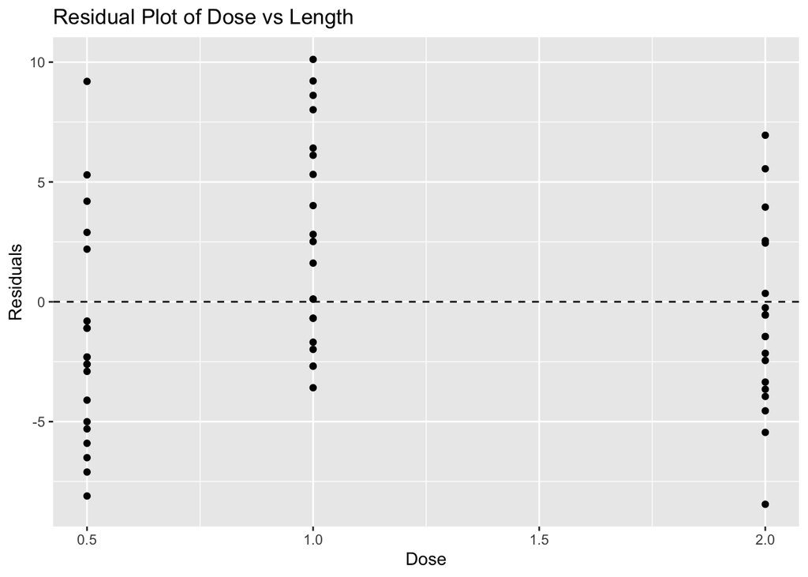

```r
# Fit linear model
model_toothgrowth <- lm(len ~ dose, data = ToothGrowth)

# Calculate residuals
residuals_toothgrowth <- resid(model_toothgrowth)

# Residual plot
ggplot(ToothGrowth, aes(x = dose, y = residuals_toothgrowth)) +
  geom_point() +
  geom_hline(yintercept = 0, linetype = "dashed") +
  labs(title = "Residual Plot of Dose vs Length", x = "Dose", y = "Residuals")
```

```r
# Make predictions
predictions <- predict(model_toothgrowth, newdata = data.frame(dose = c(0.5, 1, 3))) # 3 is extrapolated
predictions
```

```
##        1        2        3
## 12.30429 17.18607 36.71321
```

### Problem 4: Cars Dataset - Speed vs Stopping Distance

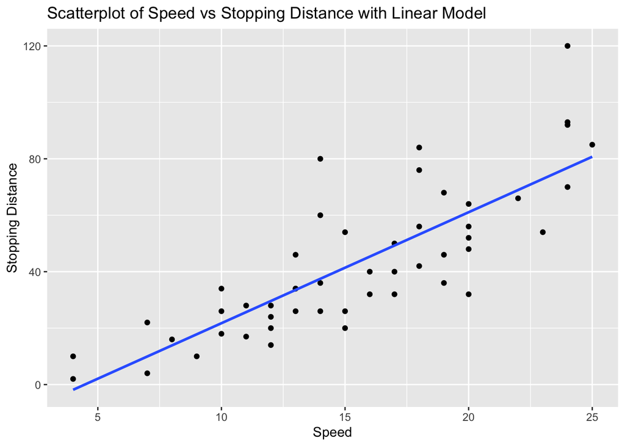

```r
# Load ggplot2 and cars dataset
library(ggplot2)
data(cars)

# Scatterplot with linear model
ggplot(cars, aes(x = speed, y = dist)) +
  geom_point() +
  geom_smooth(method = "lm", se = FALSE) +
  labs(title = "Scatterplot of Speed vs Stopping Distance with Linear Model", x = "Speed", y = "Stopping Distance")
```

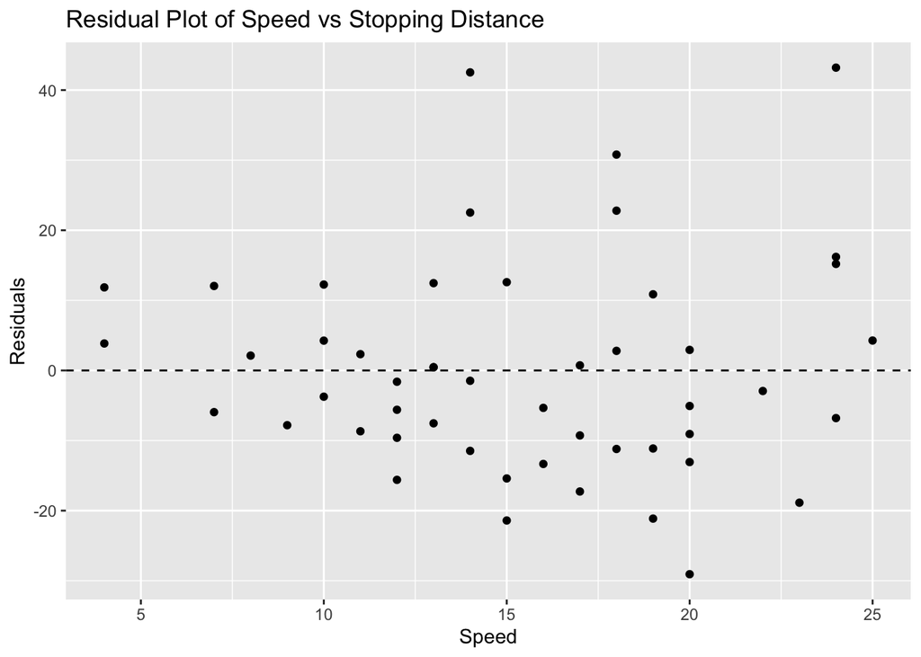

```r
# Fit linear model
model_cars <- lm(dist ~ speed, data = cars)

# Calculate residuals
residuals_cars <- resid(model_cars)

# Residual plot
ggplot(cars, aes(x = speed, y = residuals_cars)) +
  geom_point() +
  geom_hline(yintercept = 0, linetype = "dashed") +
  labs(title = "Residual Plot of Speed vs Stopping Distance", x = "Speed", y = "Residuals")
```

```r
# Make predictions
predictions <- predict(model_cars, newdata = data.frame(speed = c(10, 15, 30))) # 30 is extrapolated
predictions
```

```
##         1         2         3
##  21.74499  41.40704 100.39317
```